# Overview of MPT Multiverse: An Example Application

Marius Barth and Henrik Singmann

2026-05-15

# Package Overview

`MPTmultiverse` provides a single function, `fit_mpt()`, that performs a *multiverse analysis* for multinomial processing tree models. The idea of a multiverse analysis (Steegen, Tuerlinckx, Gelman, & Vanpaemel, 2016) is to perform and report all possible combinations of reasonable modeling choices. This contrasts with a more common analysis approach in which only one specific analysis (i.e., one path through a garden of forking paths) is reported.

`fit_mpt` performs a multiverse analysis combining two different factors.

- First, it performs analyses within a *Bayesian* or a *frequentist/maximum-likelihood* statistical framework.
- Second, it performs analyses across different levels of *pooling*, that is, different levels of data aggregation. Overall, three different levels of pooling are explored: complete pooling (i.e., data completely aggregated across participants), no pooling (i.e., separate models are fitted to the individual-level data and the results are combined after fitting), and partial pooling (i.e., hierarchical models that combine group-level parameters with individual-level parameters as random-effects).

# Prerequisites

First of all, make sure that you have installed the *latest* version of `R`, of all necessary `R` packages, *and* of `JAGS`. To install `JAGS`, go to [mcmc-jags.sourceforge.net](https://mcmc-jags.sourceforge.io/) and follow installation instructions. After that, install or update the required `R` packages:

```r
install.packages("MPTmultiverse")
update.packages(ask = FALSE)
```

# Example Data: Bayen & Kuhlmann (2011)

Here we use parts of the data from Experiment 1 reported in Bayen and Kuhlmann (2011) investigating source-memory of participants under two different cognitive load conditions. The 24 participants in the `load` condition generated a random number between one and nine every time they heard a tone, which happened every 2 s during the entire study phase, and said it out loud. The 24 participants in the `no_load` condition performed the study phase without a secondary task. Participants and both conditions performed the test phase in the same manner.

We use the same model as Bayen and Kuhlman (2011), model variant 4 of the 2-high threshold source-memory model (2HTSM) introduced by Bayen, Murnane, and Erdfelder (1996). Model variant 4 of the 2HTSM separates observed source-memory data into 4 parameters: Parameter $D$ (item recognition); parameter $d$ (source memory); parameter $b$ (probability of guessing that an item is old); and parameter $g$ (probability of guessing that an item comes from source A versus source B).

Both data and model come with package `MPTmultiverse` so their location can be obtained using function `system.file`. In other applications, the file paths need to be provided by the user to match the location of data and model on their file system. It often makes sense to set the working directory to the directory in which the data and model file resides, either via `setwd()` or via the menu.

```r
# load packages
library("MPTmultiverse")

# If you're running the analysis from an .rmd file, you only need to ensure that
# the .rmd, .eqn, and .csv files are all in the same directory.

# ------------------------------------------------------------------------------
# MPT model definition & data

EQN_FILE <- system.file("extdata", "2HTSM_Submodel4.eqn", package = "MPTmultiverse")
DATA_FILE <- system.file("extdata", "Kuhlmann_dl7.csv", package = "MPTmultiverse")

# if .csv format uses semicolons ";" (German format):
data <- read.csv2(DATA_FILE, fileEncoding = "UTF-8-BOM")  ## use correct encoding if necessary

# if .csv format uses commata "," (international format):
# data <- read.csv(DATA_FILE, fileEncoding = "UTF-8-BOM")

# We first take a look at the data using head()
head(data)
```

```
#>   Subject ExpCond Yee Yeu Yen Yue Yuu Yun Yne Ynu Ynn
#> 1     110       1   6  12   5   2  18   5   0   2  14
#> 2     138       1  11   8   6   3  16   4   2   2  12
#> 3     141       1   9  10   7   1  16   5   2   1  13
#> 4     149       1  10   9   4   0  19   6   0   0  16
#> 5     102       1  12   4   8   5  11   8   0   0  16
#> 6     105       1  14   2   5   1  19   7   2   0  14
```

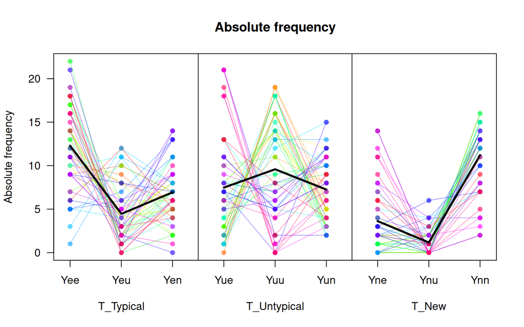

```r
## We then plot the response frequencies using plotFreq from the TreeBUGS package
TreeBUGS::plotFreq(data, boxplot = FALSE, eqn = EQN_FILE)
```

The look at the `data.frame` tells us which columns contain the subject identifier and the variable encoding group membership. We need to record these variables for the use in `fit_mpt`.

The plot of the individual response frequencies shows quite some individual variability, but nothing concerning.

Next, we prepare the data for the fitting.

```r
COL_ID <- "Subject"         # name of the variable encoding subject ID
COL_CONDITION <- "ExpCond"  # name of the variable encoding group membership


# Experimental conditions should be labeled in a meaningful way. To accomplish
# this, you may want to use the `factor` function:
unique(data[, COL_CONDITION])
```

```
#> [1] 1 2
```

```r
data[[COL_CONDITION]] <- factor(
  data[[COL_CONDITION]]
  , levels = c(1:2)
  , labels = c("no_load", "load")
)

### check input data frame
head(data)
```

```
#>   Subject ExpCond Yee Yeu Yen Yue Yuu Yun Yne Ynu Ynn
#> 1     110 no_load   6  12   5   2  18   5   0   2  14
#> 2     138 no_load  11   8   6   3  16   4   2   2  12
#> 3     141 no_load   9  10   7   1  16   5   2   1  13
#> 4     149 no_load  10   9   4   0  19   6   0   0  16
#> 5     102 no_load  12   4   8   5  11   8   0   0  16
#> 6     105 no_load  14   2   5   1  19   7   2   0  14
```

## Options

Every time the package `MPTmultiverse` is loaded, it automatically sets some more or less useful defaults for model estimation, usage of multiple processor cores, number of posterior predictive samples, etc. By calling `mpt_options()` without any parameters, you can inspect these default values. If you want to change them, call `mpt_options` with the respective parameter specified, i.e. `mpt_options(n.iter = 1000)`. For testing purposes, you can also specify `mpt_options("test")`, which is a shorthand for setting fast, but highly unreliable settings. You can set options to defaults, again, by typing the shorthand `mpt_options("default")`.

```r
# How to change a single option:
mpt_options(n.iter = 1e3)

# For testing purposes, you can use this shorthand to set fast, but unreliable options:
mpt_options("test")

# List all options that were set for the different analysis approaches:
mpt_options()
```

## Model Fitting

The main computations are performed with a call to `fit_mpt`. In the default settings, the ten analysis options offered by `MPTmultiverse` are performed. Type `?fit_mpt` in the R console if you want to see what these options are and find out more about the parameters of the function. The help page also contains a comprehensive overview of the results object returned by `fit_mpt`.

Before fitting, we set a seed to make the analysis reproducible and set the options to the default settings.

```r
set.seed(42)
mpt_options("default")

results <- fit_mpt(
  model = EQN_FILE
  , dataset = DATA_FILE
  , data = data
  , id = COL_ID
  , condition = COL_CONDITION
  , core = c("D", "d")
)
```

After fitting it is a good idea to save the results as a binary `R` data file for later. This is easiest done using `save()`. To save all information necessary to recreate the analysis we only need to save the results `tibble` as it contains both data and model as attributes (see `str(results, 1)`).

We can automatically create a file name for the file holding the results based on the model and data file.

```r
save(results, file = paste0(EQN_FILE, "-", DATA_FILE, ".RData"))
```

In the current example this would usually lead to quite a long filename (e.g., see `EQN_FILE`), so one can also use a custom filename.

```r
save(results, file = "results_bayen_kuhlmann_2HTSM4.RData")
```

One can also directly save in a subfolder of the current working directory (if the subfolder exists).

```r
save(results, file = "fits/results_bayen_kuhlmann_2HTSM4.RData")
```

## Checking the Fit

After computations finished, which may take between a couple of hours to days, check if model estimation worked by using the function `check_results`.

```r
check_results(results)
```

```
#> ## MPTinR: no pooling
#> Based on asymptotic method, proportion of participants with non-identified parameters:
#>   condition core  proportion
#> 1 load      FALSE     0
#> 2 load      TRUE      0.0417
#> 3 no_load   FALSE     0.0208
#> 4 no_load   TRUE      0.0208
#>
#> Based on asymptotic CIs, table of non-identified parameters:
#>   condition core  parameter     n
#> 1 load      TRUE  d             2
#> 2 no_load   FALSE g             1
#> 3 no_load   TRUE  d             1
#>
#> Based on PB/MLE method, proportion of participants with non-identified parameters:
#>   condition core  proportion
#> 1 load      FALSE     0
#> 2 load      TRUE      0.354
#> 3 no_load   FALSE     0.0625
#> 4 no_load   TRUE      0
#>
#> Based on PB/MLE CIs, table of non-identified parameters:
#>   condition core  parameter     n
#> 1 load      TRUE  d            17
#> 2 no_load   FALSE g             3
#>
#> Based on NPB/MLE method, proportion of participants with non-identified parameters:
#>   condition core  proportion
#> 1 load      FALSE     0
#> 2 load      TRUE      0.354
#> 3 no_load   FALSE     0.0625
#> 4 no_load   TRUE      0
#>
#> Based on NPB/MLE CIs, table of non-identified parameters:
#>   condition core  parameter     n
#> 1 load      TRUE  d            17
#> 2 no_load   FALSE g             3
#>
#>
#> ## MPTinR: complete pooling
```

[output cut: 22 more lines]

```
#>
#> ## /home/mariusbarth/R/x86_64-pc-linux-gnu-library/3.6/MPTmultiverse/extdata/2HTSM_Submodel4.eqn // /home/mariusbarth/R/x86_64-pc-linux-gnu-library/3.6/MPTmultiverse/extdata/Kuhlmann_dl7.csv // partial // TreeBUGS // beta:
#>   All Rhat < 1.05 .
#>   5  core parameters with effect sample size n.eff < 2000 :
#> alph[d], alph[D], bet[d], bet[D], mean[d]
#>   0  auxiliary parameters with effect sample size n.eff < 2000 :
#>
#>
#>
#> ## /home/mariusbarth/R/x86_64-pc-linux-gnu-library/3.6/MPTmultiverse/extdata/2HTSM_Submodel4.eqn // /home/mariusbarth/R/x86_64-pc-linux-gnu-library/3.6/MPTmultiverse/extdata/Kuhlmann_dl7.csv // partial // TreeBUGS // betacpp:
#>   All Rhat < 1.05 .
#>   12  core parameters with effect sample size n.eff < 2000 :
#> sd[d], sd[D], alph[d], alph[D], bet[d], bet[D], mean[d], alph[d], alph[D], bet[d], bet[D], d[21]
#>   0  auxiliary parameters with effect sample size n.eff < 2000 :
#>
```

## Returned Object

`fit_mpt` returns a `tibble` with an additional class, `multiverseMPT`, with one row per estimation method. When using the default setting and if all methods succeed, `fit_mpt` uses ten estimation methods and thus this `tibble` contains ten rows. The first five columns contain information about data and method and the remaining columns contain the results. Most of the results columns are `list` columns and inspection of the content is performed most conveniently using packages `dplyr` and `tidyr`. We therefore load these packages before taking a glimpse at the columns.

```r
library("dplyr")
library("tidyr")
glimpse(results)
```

```
#> Rows: 10
#> Columns: 18
#> $ model            <chr> "/home/mariusbarth/R/x86_64-pc-linux-gnu-library/3.6/…
#> $ dataset          <chr> "/home/mariusbarth/R/x86_64-pc-linux-gnu-library/3.6/…
#> $ pooling          <chr> "complete", "no", "no", "no", "no", "complete", "part…
#> $ package          <chr> "MPTinR", "MPTinR", "MPTinR", "MPTinR", "TreeBUGS", "…
#> $ method           <chr> "asymptotic", "asymptotic", "PB/MLE", "NPB/MLE", "sim…
#> $ est_group        <list> [<tbl_df[8 x 9]>], [<tbl_df[8 x 9]>], [<tbl_df[8 x 9…
#> $ est_indiv        <list> [<tbl_df[0 x 0]>], [<tbl_df[192 x 11]>], [<tbl_df[19…
#> $ est_rho          <list> [<tbl_df[0 x 3]>], [<tbl_df[0 x 3]>], [<tbl_df[0 x 3…
#> $ test_between     <list> [<tbl_df[4 x 11]>], [<tbl_df[4 x 11]>], [<tbl_df[4 x…
#> $ test_within      <list> [<tbl_df[12 x 14]>], [<tbl_df[12 x 14]>], [<tbl_df[1…
#> $ gof              <list> [<tbl_df[1 x 6]>], [<tbl_df[1 x 6]>], [<tbl_df[1 x 6…
#> $ gof_group        <list> [<tbl_df[2 x 7]>], [<tbl_df[2 x 7]>], [<tbl_df[2 x 7…
#> $ gof_indiv        <list> [<tbl_df[0 x 0]>], [<tbl_df[48 x 8]>], [<tbl_df[48 x…
#> $ fungibility      <list> [<tbl_df[0 x 3]>], [<tbl_df[0 x 3]>], [<tbl_df[0 x 3…
#> $ test_homogeneity <list> [<tbl_df[2 x 4]>], [<tbl_df[2 x 4]>], [<tbl_df[2 x 4…
#> $ convergence      <list> [<tbl_df[3 x 4]>], [<tbl_df[48 x 5]>], [<tbl_df[48 x…
#> $ estimation       <list> [<tbl_df[4 x 2]>], [<tbl_df[1 x 2]>], [<tbl_df[1 x 2…
#> $ options          <list> [<tbl_df[1 x 14]>], [<tbl_df[1 x 14]>], [<tbl_df[1 x…
```

Bayen and Kuhlman (2011) report a difference in the $g$ parameter across conditions (they actually report an interaction with a further within-subjects factor, but this is not considered here). Thus, we can take a look at the difference in $g$ parameter across conditions and methods in the following manner: We first select the column containing the results of the between-condition tests, `unnest` this column, and then select only data containing the relevant parameter.

```r
results %>%
  select(pooling:method, test_between) %>%
  unnest(cols = test_between) %>%
  filter(parameter == "g") %>%
  print(width = 150)
```

```
#> # A tibble: 10 × 14
#>    pooling  package  method             parameter core  condition1 condition2
#>    <chr>    <chr>    <chr>              <chr>     <lgl> <chr>      <chr>
#>  1 complete MPTinR   asymptotic         g         FALSE no_load    load
#>  2 no       MPTinR   asymptotic         g         FALSE no_load    load
#>  3 no       MPTinR   PB/MLE             g         FALSE no_load    load
#>  4 no       MPTinR   NPB/MLE            g         FALSE no_load    load
#>  5 no       TreeBUGS simple             g         FALSE no_load    load
#>  6 complete TreeBUGS simple             g         FALSE no_load    load
#>  7 partial  TreeBUGS trait              g         FALSE no_load    load
#>  8 partial  TreeBUGS trait_uncorrelated g         FALSE no_load    load
#>  9 partial  TreeBUGS beta               g         FALSE no_load    load
#> 10 partial  TreeBUGS betacpp            g         FALSE no_load    load
#>    est_diff     se       p ci_0.025 ci_0.1  ci_0.9 ci_0.975
#>       <dbl>  <dbl>   <dbl>    <dbl>  <dbl>   <dbl>    <dbl>
#>  1   -0.186 0.0316 NA        -0.248 -0.227 -0.146  -0.125
#>  2   -0.151 0.0781  0.0587   -0.304 -0.251 -0.0511  0.00189
#>  3   -0.133 0.0808  0.104    -0.292 -0.237 -0.0298  0.0250
#>  4   -0.133 0.0808  0.104    -0.292 -0.237 -0.0298  0.0250
#>  5   -0.145 0.0281  0        -0.200 -0.181 -0.109  -0.0888
#>  6   -0.187 0.0312  0        -0.247 -0.227 -0.147  -0.126
#>  7   -0.184 0.0978  0.0693   -0.370 -0.308 -0.0582  0.0157
#>  8   -0.199 0.0949  0.0462   -0.379 -0.318 -0.0759 -0.00323
#>  9   -0.153 0.0710  0.0360   -0.289 -0.243 -0.0611 -0.0110
#> 10   -0.152 0.0712  0.0385   -0.288 -0.242 -0.0609 -0.00990
```

Inspecting the differences across the analysis multiverse shows that the estimated difference is negative in each case and the 95% credibility/confidence intervals around the estimate do not include zero for 6 out of the 10 methods. Only the CIs for the no-pooling frequentist methods as well as the most sophisticated model, the latent trait model, include 0. However, the 80% CIs do not include zero for all methods. Taken together, this provides evidence that the $g$ parameter is larger in the `load` compared to the `no_load` condition.

In a similar manner, it is also possible to examine differences between parameter estimates *within* each group: We first `select` the column containing within-condition tests, `unnest` this column, and then `select` only data containing the relevant parameters.

```r
results %>%
  select(pooling:method, test_within) %>%
  unnest(cols = test_within) %>%
  filter(condition == "no_load") %>%
  filter(parameter1 == "d" & parameter2 == "D") %>%
  print(width = 150)
```

```
#> # A tibble: 10 × 17
#>    pooling  package  method             condition parameter1 parameter2 core1
#>    <chr>    <chr>    <chr>              <chr>     <chr>      <chr>      <lgl>
#>  1 complete MPTinR   asymptotic         no_load   d          D          TRUE
#>  2 no       MPTinR   asymptotic         no_load   d          D          TRUE
#>  3 no       MPTinR   PB/MLE             no_load   d          D          TRUE
#>  4 no       MPTinR   NPB/MLE            no_load   d          D          TRUE
#>  5 no       TreeBUGS simple             no_load   d          D          TRUE
#>  6 complete TreeBUGS simple             no_load   d          D          TRUE
#>  7 partial  TreeBUGS trait              no_load   d          D          TRUE
#>  8 partial  TreeBUGS trait_uncorrelated no_load   d          D          TRUE
#>  9 partial  TreeBUGS beta               no_load   d          D          TRUE
#> 10 partial  TreeBUGS betacpp            no_load   d          D          TRUE
#>    core2       est     se statistic    df     p ci_0.025  ci_0.1 ci_0.9 ci_0.975
#>    <lgl>     <dbl>  <dbl>     <dbl> <dbl> <dbl>    <dbl>   <dbl>  <dbl>    <dbl>
#>  1 TRUE  -0.00493  0.0530   -0.0930    NA 0.926  -0.109  -0.0728 0.0630   0.0989
#>  2 TRUE  -0.0126   0.0542   -0.232     22 0.819  -0.125  -0.0842 0.0591   0.0999
#>  3 TRUE  -0.0216   0.0527   -0.410     23 0.686  -0.131  -0.0911 0.0479   0.0874
#>  4 TRUE  -0.0216   0.0527   -0.410     23 0.686  -0.131  -0.0911 0.0479   0.0874
#>  5 TRUE  -0.000551 0.0438   NA         NA 0.982  -0.0857 -0.0568 0.0551   0.0853
#>  6 TRUE  -0.00221  0.0526   NA         NA 0.951  -0.104  -0.0684 0.0657   0.102
#>  7 TRUE  -0.000351 0.0743   NA         NA 0.973  -0.143  -0.0925 0.0945   0.152
#>  8 TRUE  -0.00389  0.0714   NA         NA 0.944  -0.144  -0.0924 0.0865   0.141
#>  9 TRUE  -0.00505  0.0615   NA         NA 0.930  -0.125  -0.0833 0.0741   0.117
#> 10 TRUE  -0.00597  0.0604   NA         NA 0.911  -0.123  -0.0827 0.0722   0.115
```

In this example, these comparisons are probably not meaningful, but for other designs this column may be used for within-subjects comparisons.

## Plotting Results

The analysis output `results` is an object of class `multiverseMPT`, that has its own `plot()` method. The `plot` method returns `ggplot2` objects, which allows further customization (such as using `themes`). Type `?plot.multiverseMPT` to see the documentation of possible arguments to this method.

To plot group-level parameter estimates use:

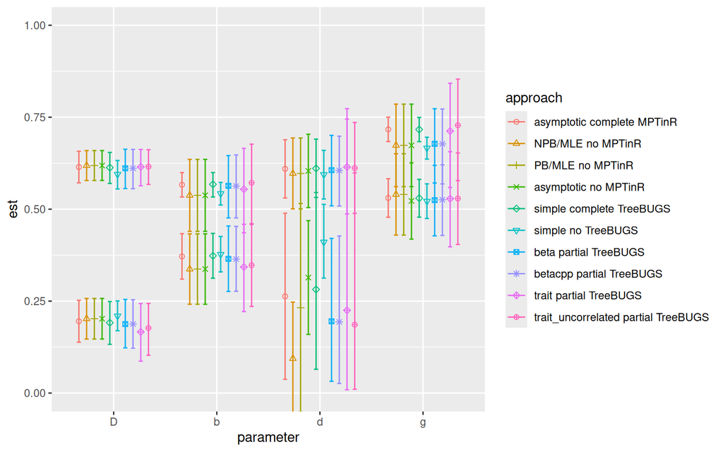

```r
plot(results, save = FALSE, "est")
```

To plot between-subjects comparisons across all parameters:

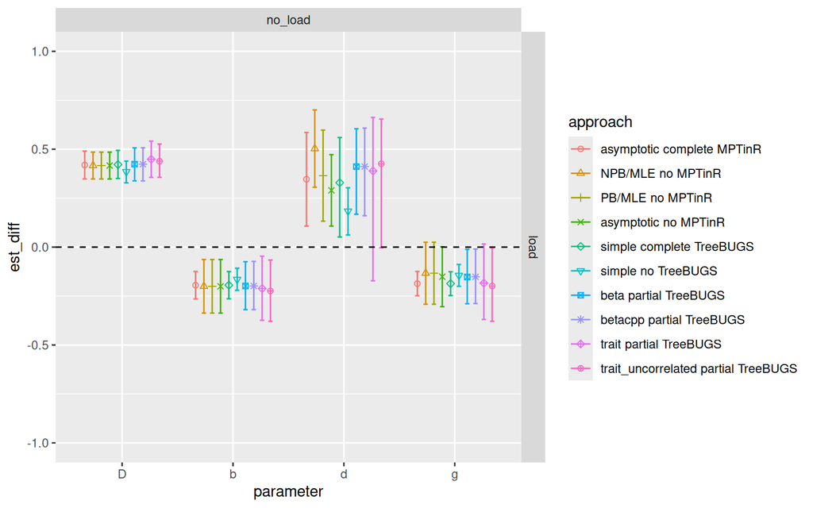

```r
plot(results, save = FALSE, "test_between")
```

To plot overall goodness-of-fit use:

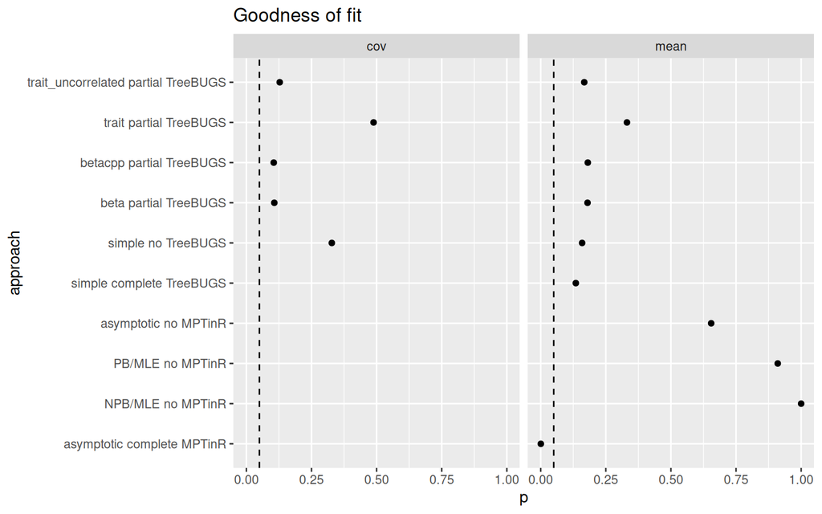

```r
plot(results, save = FALSE, "gof1")
```

To plot group-wise goodness-of-fit use:

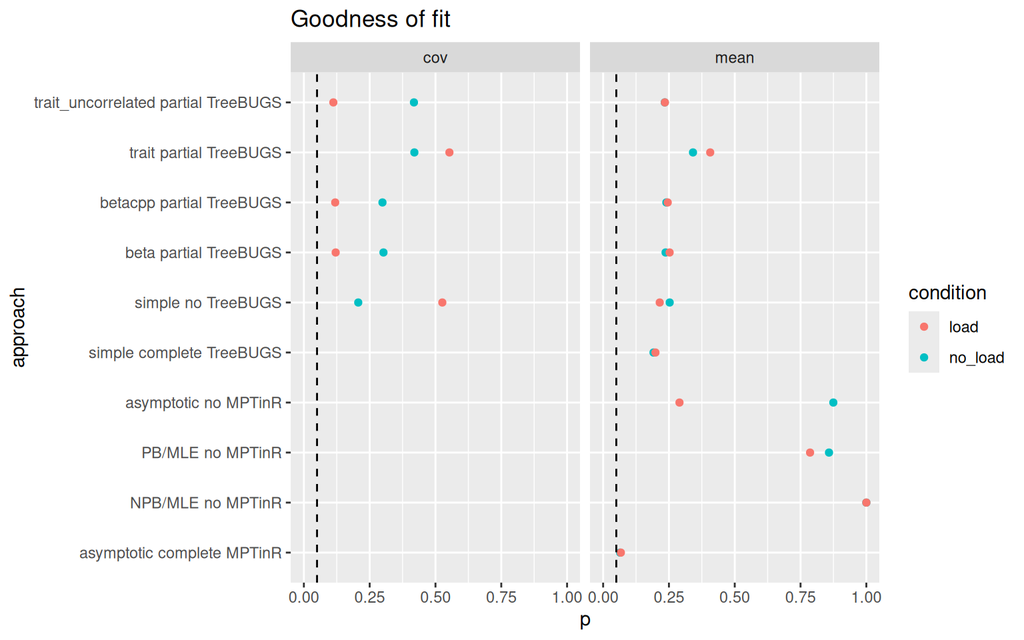

```r
plot(results, save = FALSE, "gof2")
```

# References

- Bayen, U. J., & Kuhlmann, B. G. (2011). Influences of source–item contingency and schematic knowledge on source monitoring: Tests of the probability-matching account. *Journal of Memory and Language*, 64(1), 1–17. https://doi.org/10.1016/j.jml.2010.09.001
- Bayen, U. J., Murnane, K., & Erdfelder, E. (1996). Source discrimination, item detection, and multinomial models of source monitoring. *Journal of Experimental Psychology: Learning, Memory, and Cognition*, 22(1), 197–215. https://doi.org/10.1037/0278-7393.22.1.197
- Heck, D. W., Arnold, N. R., & Arnold, D. (2017). TreeBUGS: An R package for hierarchical multinomial-processing-tree modeling. *Behavior Research Methods*, 1–21. https://doi.org/10.3758/s13428-017-0869-7
- Singmann, H., & Kellen, D. (2013). MPTinR: Analysis of multinomial processing tree models in R. *Behavior Research Methods*, 45(2), 560–575. https://doi.org/10.3758/s13428-012-0259-0
- Steegen, S., Tuerlinckx, F., Gelman, A., & Vanpaemel, W. (2016). Increasing Transparency Through a Multiverse Analysis. *Perspectives on Psychological Science*, 11(5), 702–712. https://doi.org/10.1177/1745691616658637